# Summer Lab 1

DYLAN FRANCISCO

June 30, 2023

# Lab 1a: Basic Data Transformation

## Introduction

The main purpose of this tutorial is to put together 4 key functions from **[dplyr](https://dplyr.tidyverse.org/reference/index.html)**. The functions and their purposes are listed as follows:

- `filter()` *Selects Observations Based on Values*
- `arrange()` *Sorts Observations Based on Criteria*
- `select()` or `rename()` *Selects, Deselects, Renames, and Reorders Variables*
- `mutate()` or `transmute()` *Creates New Variables Which Were Originally Nonexistant*

Despite my despise for the entire airline industry, we will practice our skills using the dataset `flights` by loading the R package `nycflights13`. My ultimate wish for you is that by the end of this tutorial you will have tenderly played with this dataset so much that you will also hate the airline industry. If my wish does not come true this hot session, be sure that it will by the end of this semester.

Now in the words of the late, great, **[Frank Sinatra](https://en.wikipedia.org/wiki/Frank_Sinatra)**, come fly with me.-

> Come fly with me, let’s fly, let’s fly away.

> – Frank Sinatra

You will need to modify the code chunks so that the code works within each of chunk (usually this means modifying anything in ALL CAPS). You will also need to modify the code outside the code chunk. When you get the desired result for each step, change `Eval=F` to `Eval=T` and knit the document to HTML to make sure it works. Do not work out of order or skip around. After you complete the lab or by the end of class, you should submit your HTML file to Canvas.

## Part 1: The Uniqueness of Flight Numbers

### 1.1 (0.5 Points)

Using `filter()`, start by creating a new tibble called **f1a** that only contains records from flight number 807.

```r
f1a<-filter(flights, flight == 807)
f1a
```

```
## # A tibble: 355 × 19
##     year month   day dep_time sched_dep_time dep_delay arr_time sched_arr_time
##    <int> <int> <int>    <int>          <int>     <dbl>    <int>          <int>
##  1  2013     1     2      744            730        14     1017           1007
##  2  2013     1     3      729            730        -1     1000           1004
##  3  2013     1     4      728            730        -2      946           1004
##  4  2013     1     5      727            730        -3      941           1004
##  5  2013     1     7      901            730        91     1118           1004
##  6  2013     1     8      729            730        -1     1004           1004
##  7  2013     1     9      727            730        -3     1015           1004
##  8  2013     1    10      727            730        -3      954           1004
##  9  2013     1    11      726            730        -4      954           1004
## 10  2013     1    12      728            730        -2      933           1004
## # ℹ 345 more rows
## # ℹ 11 more variables: arr_delay <dbl>, carrier <chr>, flight <int>,
## #   tailnum <chr>, origin <chr>, dest <chr>, air_time <dbl>, distance <dbl>,
## #   hour <dbl>, minute <dbl>, time_hour <dttm>
```

### 1.2 (0.5 Points)

Now, apply `select()` to create a new dataset **f1b** based on **f1a** only containing variables “flight”, “carrier”, “origin”, and “dest”.

```r
f1b<-select(f1a, flight, carrier, origin, dest)
f1b
```

```
## # A tibble: 355 × 4
##    flight carrier origin dest
##     <int> <chr>   <chr>  <chr>
##  1    807 DL      EWR    ATL
##  2    807 DL      EWR    ATL
##  3    807 DL      EWR    ATL
##  4    807 DL      EWR    ATL
##  5    807 DL      EWR    ATL
##  6    807 DL      EWR    ATL
##  7    807 DL      EWR    ATL
##  8    807 DL      EWR    ATL
##  9    807 DL      EWR    ATL
## 10    807 DL      EWR    ATL
## # ℹ 345 more rows
```

### 1.3 (0.5 Points)

Rename the variable “dest” to “destination” in **f1c**.

```r
f1c=rename(f1b,destination = dest)
f1c
```

```
## # A tibble: 355 × 4
##    flight carrier origin destination
##     <int> <chr>   <chr>  <chr>
##  1    807 DL      EWR    ATL
##  2    807 DL      EWR    ATL
##  3    807 DL      EWR    ATL
##  4    807 DL      EWR    ATL
##  5    807 DL      EWR    ATL
##  6    807 DL      EWR    ATL
##  7    807 DL      EWR    ATL
##  8    807 DL      EWR    ATL
##  9    807 DL      EWR    ATL
## 10    807 DL      EWR    ATL
## # ℹ 345 more rows
```

### 1.4 (0.5 Points)

Because **f1c** only contains records for flight number 807, sorting by flight number is irrelevant. Create a new dataset **f1d** that is identical in content to **f1c** but is sorted by “carrier” first, “origin” second, and “destination”” last. Use the function `head()`to display the first 5 rows of the data in **f1d**.

```r
f1d<- f1c %>%
  select(carrier, origin, destination) %>%
  arrange(carrier, origin, destination)
head(f1d, 5)
```

```
## # A tibble: 5 × 3
##   carrier origin destination
##   <chr>   <chr>  <chr>
## 1 DL      EWR    ATL
## 2 DL      EWR    ATL
## 3 DL      EWR    ATL
## 4 DL      EWR    ATL
## 5 DL      EWR    ATL
```

### 1.5 (1.5 Points)

At first glance from the output above, it seems that flight number 807 uniquely represents the flight from Newark to Atlanta by carrier Delta (Fill in the Blanks).

### 1.6 (0.5 Points)

To confirm this, create a new dataset **f1e** that is **f1d** sorted by the three variables previously mentioned, all in descending order. The function `desc()` is required here. Follow this by displaying the first 18 rows of the data in **f1d**.

```r
f1e<-arrange(f1d, desc(carrier), desc(origin), desc(destination))
head(f1e,18)
```

```
## # A tibble: 18 × 3
##    carrier origin destination
##    <chr>   <chr>  <chr>
##  1 WN      EWR    MDW
##  2 WN      EWR    MDW
##  3 WN      EWR    MDW
##  4 WN      EWR    MDW
##  5 UA      LGA    IAH
##  6 UA      LGA    IAH
##  7 UA      LGA    IAH
##  8 UA      LGA    IAH
##  9 UA      EWR    MCO
## 10 UA      EWR    MCO
## 11 UA      EWR    LAS
## 12 UA      EWR    IAH
## 13 UA      EWR    IAH
## 14 UA      EWR    IAH
## 15 UA      EWR    BOS
## 16 DL      JFK    PIT
## 17 DL      EWR    ATL
## 18 DL      EWR    ATL
```

### 1.7 (1 Point)

Answer the following questions using the output from the previous question:

May we conclude that flight numbers can be mapped to a unique carrier? No (*Yes/No*)

Why or why not? We can not conclude this because there are carriers like United (UA) and Southwest (WN)

If we know the flight number, carrier, and origin, can we know for sure what the destination will be? No (*Yes/No*)

Why or why not? We can not know for sure what the destination is, because there are examples such as: Flight 807, Carrier UA, Origin EWR. This set of flight number, carrier, and origin has destinations to LAS, IAH, and BOS.

## Part 2: Time to Get on the Pipe

In the previous section, we created a new tibble every time we wanted to perform a modification to the data. Behold the pipe `%>%`, your path to RAM-saving, sleek code and my path to coins. The pipe `%>%` is used in a similar fashion to `+` in the `ggplot2()` package. It’s time to take a magical journey through the tidyverse on the pipe.

### 2.1 (0.5 Points)

Start by using `transmute()` to create a new variable “dep_hr” based on “dep_time” which represents departure time in hours since midnight. Recall the code for this is `dep_hr=dep_time%/%100+(dep_time%%100)/60`. In the same step, do this also for “sched_dep_time”,“arr_time”, and “sched_arr_time” naming the new variables “sched_dep_hr”, “arr_hr”, and “sched_arr_hr”, respectively. Save all these new variables to a new tibble called **f2a**. Use the function `names()` to ensure that **f2a** only contains the new variables and the function `head()` to view the top 5 rows.

```r
f2a=transmute(flights,
          dep_hr=dep_time%/%100+(dep_time%%100)/60,
          sched_dep_hr=sched_dep_time%/%100+(sched_dep_time%%100)/60,
          arr_hr=arr_time%/%100+(arr_time%%100)/60,
          sched_arr_hr=sched_arr_time%/%100+(sched_arr_time%%100)/60)
names(f2a)
```

```
## [1] "dep_hr"       "sched_dep_hr" "arr_hr"       "sched_arr_hr"
```

```r
head(f2a,5)
```

```
## # A tibble: 5 × 4
##   dep_hr sched_dep_hr arr_hr sched_arr_hr
##    <dbl>        <dbl>  <dbl>        <dbl>
## 1   5.28         5.25   8.5          8.32
## 2   5.55         5.48   8.83         8.5
## 3   5.7          5.67   9.38         8.83
## 4   5.73         5.75  10.1         10.4
## 5   5.9          6      8.2          8.62
```

### 2.2 (0.5 Points)

Now we can create true delay variables, measured in hours, for both departure and arrival. Using `mutate()`, create a new variable “dep_delay_hr” which equals the difference between “dep_hr” and “sched_dep_hr”. Analogously, perform the same operation for arrival. Call the new dataset **f2b**.

```r
f2b=mutate(f2a,
           dep_delay_hr = dep_hr - sched_dep_hr,
           arr_delay_hr= arr_hr - sched_arr_hr)
head(f2b, 10)
```

```
## # A tibble: 10 × 6
##    dep_hr sched_dep_hr arr_hr sched_arr_hr dep_delay_hr arr_delay_hr
##     <dbl>        <dbl>  <dbl>        <dbl>        <dbl>        <dbl>
##  1   5.28         5.25   8.5          8.32       0.0333        0.183
##  2   5.55         5.48   8.83         8.5        0.0667        0.333
##  3   5.7          5.67   9.38         8.83       0.0333        0.550
##  4   5.73         5.75  10.1         10.4       -0.0167       -0.300
##  5   5.9          6      8.2          8.62      -0.100        -0.417
##  6   5.9          5.97   7.67         7.47      -0.0667        0.200
##  7   5.92         6      9.22         8.9       -0.0833        0.317
##  8   5.95         6      7.15         7.38      -0.0500       -0.233
##  9   5.95         6      8.63         8.77      -0.0500       -0.133
## 10   5.97         6      7.88         7.75      -0.0333        0.133
```

### 2.3 (0.5 Points)

Next, use `mutate()` again to create a new variable called “gain_hr” which is the difference between “arr_delay_hr” and “dep_delay_hr”, measured in hours. Within the same step, use the function `percent_rank()` to create a new variable “percent_gain_hr” which represents the percentiles of the previously variable you created. Notice that you can develop variables based on recently transformed variables in the same iteration of `mutate()`, but be careful little buddy because order matters. Name the new dataset **f2c**.

```r
f2c=mutate(f2b,
           gain_hr= arr_delay_hr - dep_delay_hr,
           percent_gain_hr=percent_rank(gain_hr))
head(f2c, 10)
```

```
## # A tibble: 10 × 8
##    dep_hr sched_dep_hr arr_hr sched_arr_hr dep_delay_hr arr_delay_hr gain_hr
##     <dbl>        <dbl>  <dbl>        <dbl>        <dbl>        <dbl>   <dbl>
##  1   5.28         5.25   8.5          8.32       0.0333        0.183  0.150
##  2   5.55         5.48   8.83         8.5        0.0667        0.333  0.267
##  3   5.7          5.67   9.38         8.83       0.0333        0.550  0.517
##  4   5.73         5.75  10.1         10.4       -0.0167       -0.300 -0.283
##  5   5.9          6      8.2          8.62      -0.100        -0.417 -0.317
##  6   5.9          5.97   7.67         7.47      -0.0667        0.200  0.267
##  7   5.92         6      9.22         8.9       -0.0833        0.317  0.400
##  8   5.95         6      7.15         7.38      -0.0500       -0.233 -0.183
##  9   5.95         6      8.63         8.77      -0.0500       -0.133 -0.0833
## 10   5.97         6      7.88         7.75      -0.0333        0.133  0.167
## # ℹ 1 more variable: percent_gain_hr <dbl>
```

### 2.4 (0.5 Points)

First, critically think about what this new variable “gain_hr” is measuring. When `gain_hr==0`, what does that mean about the flight? What does `gain_hr<0` and `gain_hr>0` indicate. Use `filter()` to select the observations where `percent_gain_hr<0.1` or `percent_gain_hr>0.9` in a new dataset **f2d**. The tibble **f2d** will contain the bottom 10% and top 10% of flights based off “gain_hr”.

```r
f2d<-filter(f2c, percent_gain_hr < 0.1 | percent_gain_hr > 0.9)
head(f2d, 10)
```

```
## # A tibble: 10 × 8
##    dep_hr sched_dep_hr arr_hr sched_arr_hr dep_delay_hr arr_delay_hr gain_hr
##     <dbl>        <dbl>  <dbl>        <dbl>        <dbl>        <dbl>   <dbl>
##  1   5.55         5.48   8.83         8.5        0.0667        0.333   0.267
##  2   5.7          5.67   9.38         8.83       0.0333        0.550   0.517
##  3   5.9          5.97   7.67         7.47      -0.0667        0.200   0.267
##  4   5.92         6      9.22         8.9       -0.0833        0.317   0.400
##  5   5.98         6      9.68         9.17      -0.0167        0.517   0.533
##  6   6.03         6.08   8.35         8.08      -0.0500        0.267   0.317
##  7   6.13         6      8.12         7.58       0.133         0.533   0.400
##  8   6.4          6.5    9.15         8.67      -0.100         0.483   0.583
##  9   6.4          6.5    8.67         8.5       -0.100         0.167   0.267
## 10   6.47         6.5   10.3          9.78      -0.0333        0.483   0.517
## # ℹ 1 more variable: percent_gain_hr <dbl>
```

A gain_hr<0 means that you made up time in the air and a gain_hr>0 means you lost time in the air due to departure delay. The number itself represents the number of hours you either made up or lost. A gain_hr == 0 means any delay had no effect on arrival time.

### 2.5 (0.5 Points)

Finally, sort the data using `arrange()` from largest to smallest based on the variable “percent_gain_hr”. Name the sorted tibble **f2e**.

```r
f2e<-arrange(f2d, desc(percent_gain_hr))
f2e
```

```
## # A tibble: 67,018 × 8
##    dep_hr sched_dep_hr arr_hr sched_arr_hr dep_delay_hr arr_delay_hr gain_hr
##     <dbl>        <dbl>  <dbl>        <dbl>        <dbl>        <dbl>   <dbl>
##  1 0.0833         24.0   7.97         4.63        -23.9         3.33    27.2
##  2 0.333          24.0   7.38         3.83        -23.7         3.55    27.2
##  3 0.183          24.0   6.78         3.83        -23.8         2.95    26.8
##  4 0.4            24.0   6.85         3.73        -23.6         3.12    26.7
##  5 0.217          24.0   6.32         3.83        -23.8         2.48    26.3
##  6 0.317          24.0   4.97         3.83        -23.7         1.13    24.8
##  7 0.6            23.9   6.12         4.62        -23.3         1.50    24.8
##  8 2.32           24.0   6.7          3.65        -21.7         3.05    24.7
##  9 0.117          22.8   3.63         1.58        -22.6         2.05    24.7
## 10 0.367          24.0   4.9          3.83        -23.6         1.07    24.7
## # ℹ 67,008 more rows
## # ℹ 1 more variable: percent_gain_hr <dbl>
```

### 2.6 (1 Points)

Getting the original data from **flights** to **f2e** required multiple steps. If we know what we want to do with the raw data from `flights`, we can use the pipe `%>%` to obtain the same result without intermittently introducing new tibbles into our global environment. Modify the code below so that the tibble named **f2e.pipedream** is identical to `f2e`.

```r
f2e.pipedream = flights %>%
                transmute(dep_hr=dep_time%/%100+(dep_time%%100)/60,
          sched_dep_hr=sched_dep_time%/%100+(sched_dep_time%%100)/60,
          arr_hr=arr_time%/%100+(arr_time%%100)/60,
          sched_arr_hr=sched_arr_time%/%100+(sched_arr_time%%100)/60) %>%
                mutate(dep_delay_hr = dep_hr - sched_dep_hr,
           arr_delay_hr= arr_hr - sched_arr_hr) %>%
                mutate(gain_hr= arr_delay_hr - dep_delay_hr,
           percent_gain_hr=percent_rank(gain_hr)) %>%
                filter(percent_gain_hr < 0.1 | percent_gain_hr > 0.9) %>%
                arrange(desc(percent_gain_hr))
f2e.pipedream
```

```
## # A tibble: 67,018 × 8
##    dep_hr sched_dep_hr arr_hr sched_arr_hr dep_delay_hr arr_delay_hr gain_hr
##     <dbl>        <dbl>  <dbl>        <dbl>        <dbl>        <dbl>   <dbl>
##  1 0.0833         24.0   7.97         4.63        -23.9         3.33    27.2
##  2 0.333          24.0   7.38         3.83        -23.7         3.55    27.2
##  3 0.183          24.0   6.78         3.83        -23.8         2.95    26.8
##  4 0.4            24.0   6.85         3.73        -23.6         3.12    26.7
##  5 0.217          24.0   6.32         3.83        -23.8         2.48    26.3
##  6 0.317          24.0   4.97         3.83        -23.7         1.13    24.8
##  7 0.6            23.9   6.12         4.62        -23.3         1.50    24.8
##  8 2.32           24.0   6.7          3.65        -21.7         3.05    24.7
##  9 0.117          22.8   3.63         1.58        -22.6         2.05    24.7
## 10 0.367          24.0   4.9          3.83        -23.6         1.07    24.7
## # ℹ 67,008 more rows
## # ℹ 1 more variable: percent_gain_hr <dbl>
```

The tibble **f2e.pipedream** should identical to **f2e** in the number of observations (67,018), the number of variables (8), and the order of observations. We can check to see if the tibble **f2e** is identical to **f2e.pipedream** using `identical()`. You should see the function return `True` Can you feel the sensation? It’s piping hot up in here.

```r
identical(f2e,f2e.pipedream)
```

```
## [1] TRUE
```

## Part 3: Measuring Accuracy

### 3.1 (0.5 Points)

How would you measure the accuracy of individual flights? We can say that a flight is accurate if it leaves on time and arrives on time. Suppose we want to create an accuracy measure that captures this information where larger values indicate more inaccurate flights. Try to think of a creative way to measure accuracy by using `mutate()` to construct a new variable named “accuracy”. Call the new tibble `f.accuracy`. As a data scientist, the metric you want is not always in the raw data. This is an example of problem that requires a level of innovation for which a job will grant you some cash money.

```r
f.accuracy<- flights %>%
                mutate (dep_hr=dep_time%/%100+(dep_time%%100)/60,
                        sched_dep_hr=sched_dep_time%/%100+(sched_dep_time%%100)/60,
                        arr_hr=arr_time%/%100+(arr_time%%100)/60,
                        sched_arr_hr=sched_arr_time%/%100+(sched_arr_time%%100)/60,
                        dep_delay_hr=dep_hr-sched_dep_hr,
                        arr_delay_hr=arr_hr-sched_arr_hr,
                        accuracy= sqrt(dep_delay_hr^2 + arr_delay_hr^2)) %>%
                select(accuracy, everything())
head(f.accuracy,5)
```

```
## # A tibble: 5 × 26
##   accuracy  year month   day dep_time sched_dep_time dep_delay arr_time
##      <dbl> <int> <int> <int>    <int>          <int>     <dbl>    <int>
## 1    0.186  2013     1     1      517            515         2      830
## 2    0.340  2013     1     1      533            529         4      850
## 3    0.551  2013     1     1      542            540         2      923
## 4    0.300  2013     1     1      544            545        -1     1004
## 5    0.428  2013     1     1      554            600        -6      812
## # ℹ 18 more variables: sched_arr_time <int>, arr_delay <dbl>, carrier <chr>,
## #   flight <int>, tailnum <chr>, origin <chr>, dest <chr>, air_time <dbl>,
## #   distance <dbl>, hour <dbl>, minute <dbl>, time_hour <dttm>, dep_hr <dbl>,
## #   sched_dep_hr <dbl>, arr_hr <dbl>, sched_arr_hr <dbl>, dep_delay_hr <dbl>,
## #   arr_delay_hr <dbl>
```

### 3.2 (1 Points)

Preparing for comparisons of airline carriers on accuracy, we use the `select()` function to create a new tibble named `f.accuracy2` which only contains the variables “carrier” and “accuracy”.

```r
f.accuracy2=select(f.accuracy,carrier,accuracy)
```

Next, we can evaluate carriers based on their average accuracy across all flights based on our new metric. Furthermore, the standard deviation of this accuracy metric can help us measure the consistency of these airline carriers in performance. Use the `summarize()` function combined with `group_by()` for quick aggregation on the carrier level. Calculate the average accuracy and the standard deviation of the accuracy for each carrier

```r
carrier.summary<- f.accuracy2 %>%
                  group_by(carrier) %>%
                  summarize(
                    mean.accuracy=mean(accuracy,na.rm=T),
                    sd.accuracy=sd(accuracy,na.rm=T)
                  ) %>%
                  arrange(mean.accuracy)
carrier.summary
```

```
## # A tibble: 16 × 3
##    carrier mean.accuracy sd.accuracy
##    <chr>           <dbl>       <dbl>
##  1 US              0.442       1.20
##  2 HA              0.459       0.495
##  3 OO              0.645       0.909
##  4 AS              0.688       1.81
##  5 AA              0.706       2.20
##  6 MQ              0.730       2.33
##  7 WN              0.753       2.30
##  8 F9              0.777       1.80
##  9 YV              0.778       1.53
## 10 DL              0.818       2.86
## 11 9E              0.929       2.67
## 12 FL              0.956       3.10
## 13 UA              0.998       3.39
## 14 VX              1.14        3.74
## 15 EV              1.19        3.62
## 16 B6              1.92        5.60
```

# Lab 1b: Advanced Data Transformation

## Introduction

The main purpose of this tutorial is to put together all 5 key functions from **[dplyr](https://dplyr.tidyverse.org/reference/index.html)** and use them to create summary tables and delightful graphs in RMarkdown. The functions and their purposes are listed as follows:

- `filter()` *Selects Observations Based on Values*
- `arrange()` *Sorts Observations Based on Criteria*
- `select()` or `rename()` *Selects, Deselects, Renames, and Reorders Variables*
- `mutate()` or `transmute()` *Creates New Variables Which Were Originally Nonexistant*
- `summarize()` *Aggregates the Data Based on Helpful Summary Statistics*

To further incite your anger towards the airline industry, we will continue to practice our skills using the dataset `flights` by loading the R package `nycflights13`. Until we learn how to fly, this dataset remains relevant.

> I’ll spread my wings, and learn how to fly. I’ll do what it takes till I touch the sky.

> – Kelly Clarkson

## Part 1: Summarizing the Data (4 Points)

Using the pipe `%>%` to chain functions from `dplyr`, modify the code below to create a dataset named `flight.summary` that contains the following ordered modfications:

1. Starts with the raw dataset `flights` in the package `nycflights13`.
2. Transform delay variables so that they are measured in minutes since midnight, and then create a metric to measure accuracy based on those transformed delay variables. **Use the geometric distance like seen in lecture.**
3. Remove missing observations.
4. Group data based on combinations of “origin”, “dest”, and “carrier”.
5. Summarize the data using the number of observations, the accuracy mean, the accuracy variance, and the mean distance for each combination of “origin”, “dest”, and “carrier”.
6. Filters summarized data to remove all combinations of “origin”, “dest”, and “carrier” with less than or equal to 10 flights throughout 2013.
7. Release the grouping constraint using the function `ungroup()`.
8. Create a variable called “proportion”” that represents the proportion of flights within each combination (with more than 10 flights).

```r
flight.summary =

  #1
  flights %>%

  #2
  mutate(
    dep_min       = (dep_time%/%100)*60+dep_time%%100,
    sched_dep_min = (sched_dep_time%/%100)*60+sched_dep_time%%100,
    arr_min       = (arr_time%/%100)*60+arr_time%%100,
    sched_arr_min = (sched_arr_time%/%100)*60+sched_arr_time%%100,
    dep_delay_min = dep_min-sched_dep_min,
    arr_delay_min = arr_min-sched_arr_min,
    accuracy      = sqrt(dep_delay_min^2 + arr_delay_min^2)
  ) %>%

  #3
  filter(!is.na(dep_min),
         !is.na(sched_dep_min),
         !is.na(arr_min),
         !is.na(sched_arr_min),
         !is.na(dep_delay_min),
         !is.na(arr_delay_min),
         !is.na(accuracy)) %>%

  #4
  group_by(origin, dest, carrier) %>%

  #5
  summarize(
    count=n(),
    mean.acc=mean(accuracy,na.rm=T),
    var.acc=var(accuracy, na.rm=T),
    mean.dist=mean(distance, na.rm=T)
  ) %>%

  #6
  filter(!(count <= 10)) %>%

  #7
  ungroup() %>%

  #8
  mutate(proportion = count/sum(count))
head(flight.summary) #DO NOT CHANGE THIS LINE OF CODE
```

```
## # A tibble: 6 × 8
##   origin dest  carrier count mean.acc var.acc mean.dist proportion
##   <chr>  <chr> <chr>   <int>    <dbl>   <dbl>     <dbl>      <dbl>
## 1 EWR    ALB   EV        418     58.8  28201.       143   0.00127
## 2 EWR    ATL   DL       3122     36.1  13072.       746   0.00952
## 3 EWR    ATL   EV       1658     74.4  49801.       746   0.00506
## 4 EWR    ATL   UA        102     35.2   4422.       746   0.000311
## 5 EWR    AUS   UA        664    149.  152048.      1504   0.00203
## 6 EWR    AUS   WN        295     23.3    515.      1504   0.000900
```

## Part 2: Building Charts From Summary Data

### 2.1 (1 Point)

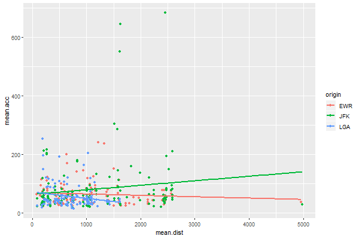

The purpose of creating this plot was to investigate if flight accuracy gets worse or better for longer flights. The chart above displays the approximated linear relationship between flight accuracy and flight distance for each the 3 NYC airports. This first image was created using a combination of `geom_point()` and `geom_smooth()`. Recreate this image using `ggplot()` and remember to modify the defaults of `geom_smooth()` to get linear trend lines without standard error regions.

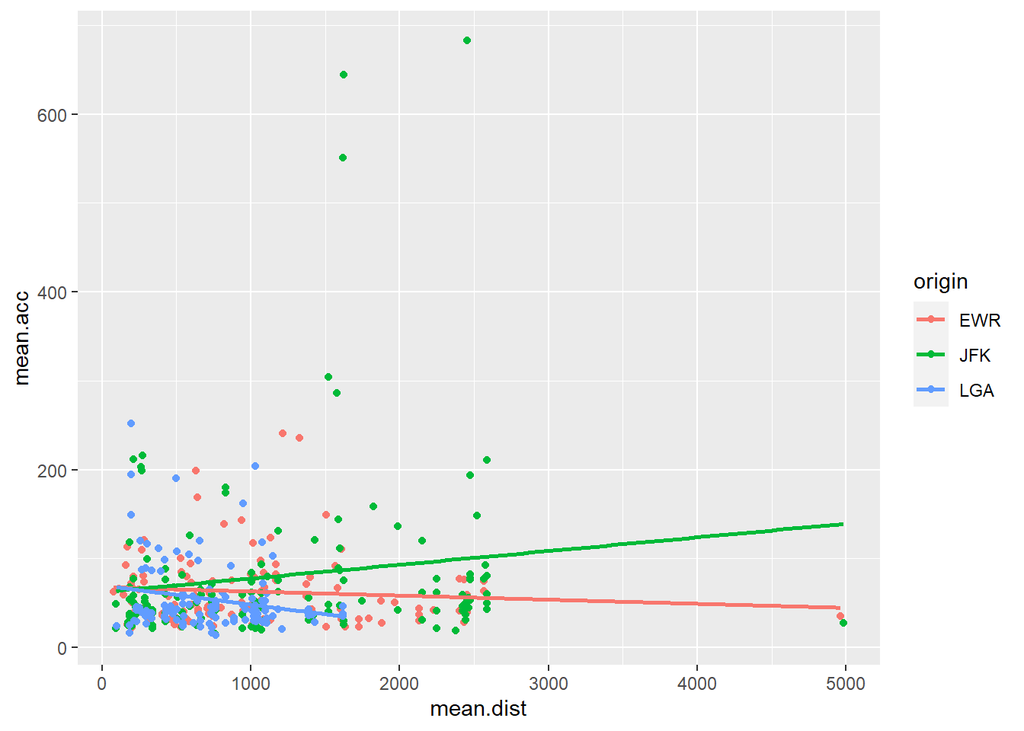

```r
ggplot(data=flight.summary) +
  geom_point(mapping = aes(x = mean.dist, y = mean.acc,
             color = origin))+
  geom_smooth(mapping = aes(x = mean.dist, y = mean.acc,
              color = origin),
              se = FALSE,
              method='lm')
```

### 2.2 (1 Point)

The first thing we notice is that not many flights are over 3000 miles in distance. Design a new plot similar to the one above that ignores the scenarios where the distance exceeds 3000. This will prevent rare occurrences from effecting our linear trend comparison and present these relationships in a zoomed-in window where the majority of data exists.

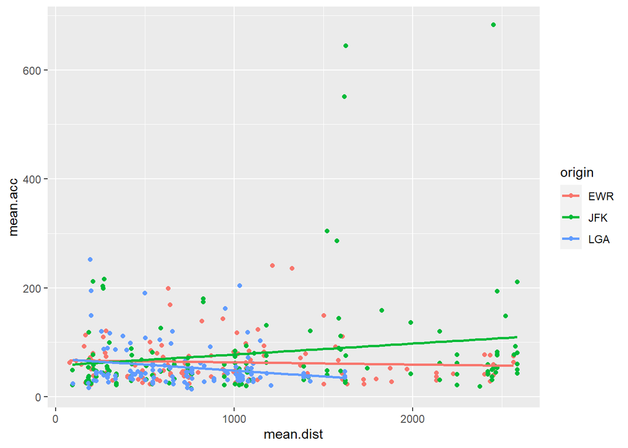

```r
ggplot(data=filter(flight.summary, !mean.dist > 3000)) +
  geom_point(mapping = aes(x = mean.dist, y = mean.acc,
             color = origin))+
  geom_smooth(mapping = aes(x = mean.dist, y = mean.acc,
              color = origin),
              se = FALSE,
              method='lm')
```

### 2.2 (1 Point)

Answer the following question using complete sentences:

## Part 3: Build a Nice Table to Be Displayed in RMarkdown (1 Point)

The dataset we created, `flight.summary`, summarizes the raw data but still contains 370 observations. Below I have provided code, that produces a dataset called `flight.summary2` that only contains the top 5 and bottom 5 combinations of “origin”, “dest”, and “carrier” based on mean accuracy. Closely examine this code and ensure that you understand what is happening here. Set `eval=T` to create `flight.summary2`.

```r
flight.summary2 =
  flight.summary %>%
  mutate(rank=min_rank(mean.acc)) %>%
  filter(min_rank(mean.acc)<=5 | min_rank(desc(mean.acc))<=5) %>%
  arrange(rank)
```

The `kable()` function in the `knitr` package allows for creating HTML tables. For information about the `kable` package, click **[here](https://bookdown.org/yihui/rmarkdown-cookbook/kable.html)** Furthermore, the `kableExtra` package allows you to add beauty to those internet-ready tables. Click **[here](http://haozhu233.github.io/kableExtra/awesome_table_in_html.html)** for a helpful introduction.

Once you understand the function of `kable()` and the modifications you can apply, start an R code chunk to place the information required to produce an HTML table of `flight.summary2`.

```r
kable(flight.summary2, align = rep("c"), eval = TRUE)
```

| origin | dest | carrier | count | mean.acc | var.acc | mean.dist | proportion | rank |
| --- | --- | --- | --- | --- | --- | --- | --- | --- |
| LGA | ATL | WN | 58 | 13.36929 | 242.44209 | 762 | 0.0001769 | 1 |
| JFK | ATL | 9E | 52 | 15.62128 | 218.70058 | 760 | 0.0001586 | 2 |
| LGA | MKE | FL | 55 | 16.20487 | 135.61337 | 738 | 0.0001678 | 3 |
| LGA | BWI | WN | 15 | 16.59889 | 40.51103 | 185 | 0.0000458 | 4 |
| JFK | PSP | VX | 18 | 18.45296 | 119.81122 | 2378 | 0.0000549 | 5 |
| JFK | BQN | B6 | 595 | 285.88231 | 302627.44331 | 1576 | 0.0018148 | 366 |
| JFK | AUS | B6 | 744 | 304.17699 | 307316.77140 | 1521 | 0.0022693 | 367 |
| JFK | PSE | B6 | 361 | 550.42912 | 461036.47240 | 1617 | 0.0011011 | 368 |
| JFK | DEN | B6 | 337 | 644.03267 | 484962.76144 | 1626 | 0.0010279 | 369 |
| JFK | PDX | B6 | 324 | 682.58293 | 484372.08218 | 2454 | 0.0009882 | 370 |

## Part 4: Additional Questions (2 Points)

In this class you will be forced to analyze data you probably care very little about. *This is the part in the class where you begin to act like you care.* An important rule in this class is to “love thy data as thyself.” Consider the `flights` data from both the view of the airline executive and the customer. Given what you know about the data, write two questions that you would want to answer that would influence how you buy airline tickets.

With this data, you could ask: Does the distance of a flight effect the accuracy of the flight, in terms of how delayed the arrival and departure are.

We could use the extra data of customer purchase to ask: Does the total accuracy of an airline effect how much customers decided to purchase tickets with that flight.